# Hotel Booking Cancellation Prediction

### Walkthrough for stakeholders and technical reviewers

This notebook tells the full story of the project: the business problem, the data, how it was cleaned and explored, five machine learning models trained and compared, the winning model then tuned and hardened against data leakage, how predictions are served, and how experiments are tracked.

Every number and graph in this notebook is generated live from the files in this repository — nothing is invented. Heavy logic lives in `src/`; this notebook calls into it and narrates the results.

## Setup

```python
import sys
from pathlib import Path

# Make the project root importable whether this notebook is run from notebooks/ or root.
ROOT = Path.cwd()
root = ROOT if (ROOT / "src").exists() else ROOT.parent
sys.path.insert(0, str(root))

import numpy as np
import pandas as pd
import matplotlib.pyplot as plt
import seaborn as sns
from IPython.display import Image, display

sns.set_style("whitegrid")
reports_dir = root / "reports"
models_dir = root / "models"
pd.set_option("display.max_columns", 40)
```

## 1. Executive Summary

**Business problem.** Hotels lose revenue when bookings cancel unexpectedly — a room that could have been resold sits empty, or gets resold last-minute at a discount. Today, most hotels only find out a booking has cancelled *after* it happens, leaving no time to react.

**Goal.** Predict, in advance, whether a booking will cancel — and how confident the model is (a probability, not just yes/no). For example: *"this booking is 92% likely to cancel."*

**How we got there.** A five-model comparison (Sections 6–9) selected XGBoost as the strongest algorithm on this data. From that baseline the model was **hyperparameter-tuned** with Optuna (Section 10b), its high-cardinality ID columns (`agent`/`company`) were **recast as native categoricals** so they became interpretable rather than meaningless magnitudes (Section 10c), and SHAP (Section 10d) then exposed two features that are only known *after* a booking exists. **Removing that leakage** (Section 10e) cost a little headline performance but produced a model whose score is honest at the moment it would actually run.

**Business value:**

- **Inventory planning** — more accurate, per-booking overbooking decisions instead of one flat historical average.
- **Customer outreach** — proactively follow up on high-risk bookings (confirmation calls, deposit reminders) before they cancel.
- **Pricing decisions** — channel- and segment-level cancellation risk can inform rate strategy and deposit policy.
- **Reduced lost revenue** — every cancellation caught early is a room that can be resold instead of discovered empty at the last minute.

This is a **decision-support tool** — it informs staff judgment, it does not replace it (more on this in Section 15).

## 2. Dataset Overview

Each **row** in the dataset is one hotel booking — a single reservation record, whether it was ultimately kept or cancelled.

```python
from src.data_loader import load_hotel_booking_data, get_default_hotel_booking_path

df_raw = load_hotel_booking_data(get_default_hotel_booking_path())
print(f"Shape: {df_raw.shape[0]:,} bookings x {df_raw.shape[1]} columns")
df_raw.head()
```

```
Shape: 119,390 bookings x 32 columns
```

|  | hotel | is_canceled | lead_time | arrival_date_year | arrival_date_month | arrival_date_week_number | arrival_date_day_of_month | stays_in_weekend_nights | stays_in_week_nights | adults | children | babies | meal | country | market_segment | distribution_channel | is_repeated_guest | previous_cancellations | previous_bookings_not_canceled | reserved_room_type | assigned_room_type | booking_changes | deposit_type | agent | company | days_in_waiting_list | customer_type | adr | required_car_parking_spaces | … |
| --- | --- | --- | --- | --- | --- | --- | --- | --- | --- | --- | --- | --- | --- | --- | --- | --- | --- | --- | --- | --- | --- | --- | --- | --- | --- | --- | --- | --- | --- | --- |
| 0 | Resort Hotel | 0 | 342 | 2015 | July | 27 | 1 | 0 | 0 | 2 | 0.0 | 0 | BB | PRT | Direct | Direct | 0 | 0 | 0 | C | C | 3 | No Deposit | NaN | NaN | 0 | Transient | 0.0 | 0 | … |
| 1 | Resort Hotel | 0 | 737 | 2015 | July | 27 | 1 | 0 | 0 | 2 | 0.0 | 0 | BB | PRT | Direct | Direct | 0 | 0 | 0 | C | C | 4 | No Deposit | NaN | NaN | 0 | Transient | 0.0 | 0 | … |
| 2 | Resort Hotel | 0 | 7 | 2015 | July | 27 | 1 | 0 | 1 | 1 | 0.0 | 0 | BB | GBR | Direct | Direct | 0 | 0 | 0 | A | C | 0 | No Deposit | NaN | NaN | 0 | Transient | 75.0 | 0 | … |
| 3 | Resort Hotel | 0 | 13 | 2015 | July | 27 | 1 | 0 | 1 | 1 | 0.0 | 0 | BB | GBR | Corporate | Corporate | 0 | 0 | 0 | A | A | 0 | No Deposit | 304.0 | NaN | 0 | Transient | 75.0 | 0 | … |
| 4 | Resort Hotel | 0 | 14 | 2015 | July | 27 | 1 | 0 | 2 | 2 | 0.0 | 0 | BB | GBR | Online TA | TA/TO | 0 | 0 | 0 | A | A | 0 | No Deposit | 240.0 | NaN | 0 | Transient | 98.0 | 0 | … |

**The target variable is `is_canceled`**: `0` = the booking was kept (guest stayed or the reservation completed normally), `1` = the booking was cancelled. This is what every model in this notebook predicts.

**Key features and why each is useful:**

| Feature | What it is | Why it's useful |
| --- | --- | --- |
| `lead_time` | Days between booking and arrival | More time = more chance plans change |
| `deposit_type` | No Deposit / Non Refund / Refundable | Strongest single signal in this dataset (see Section 4) |
| `market_segment` | How the booking was sold (Direct, Online TA, Corporate...) | Different channels attract different guest commitment |
| `previous_cancellations` | Guest's cancellation history with this hotel | Past behavior predicts future behavior |
| `total_of_special_requests` | Count of special requests made | Proxy for how invested the guest is in the specific stay |
| `adr` | Average Daily Rate (price per night) | Booking economics |
| `hotel` | City Hotel or Resort Hotel | Different guest profiles and travel purposes |
| `customer_type` | Transient / Contract / Group / Transient-Party | Individual vs. committed/negotiated bookings behave differently |

```python
missing = df_raw.isnull().sum()
missing = missing[missing > 0].sort_values(ascending=False)
missing_pct = (missing / len(df_raw) * 100).round(2)
pd.DataFrame({"missing_count": missing, "missing_pct": missing_pct})
```

|  | missing_count | missing_pct |
| --- | --- | --- |
| company | 112593 | 94.31 |
| agent | 16340 | 13.69 |
| country | 488 | 0.41 |
| children | 4 | 0.00 |

```python
counts = df_raw["is_canceled"].value_counts().sort_index()
pd.DataFrame({
    "label": ["Not Cancelled (0)", "Cancelled (1)"],
    "count": counts.values,
    "share_pct": (counts.values / counts.sum() * 100).round(2),
})
```

|  | label | count | share_pct |
| --- | --- | --- | --- |
| 0 | Not Cancelled (0) | 75166 | 62.96 |
| 1 | Cancelled (1) | 44224 | 37.04 |

**Reading these two tables:** only four columns have any missing data at all — `company` (94.3% missing), `agent` (13.7%), `country` (0.4%), and `children` (~0%) — everything else is complete. The target is moderately imbalanced: **37.0% of bookings cancel**, 63.0% don't. That imbalance is real but manageable — not so extreme that the model can't learn, but enough that plain accuracy alone would be a misleading scorecard (Section 7 explains why).

## 3. Data Cleaning and Preprocessing

Raw booking data can't go directly into a machine learning model — it has missing values, text categories a model can't do arithmetic on, and (critically) a couple of columns that would let the model "cheat." Here's what's done to fix that, and why.

**Missing values:**

- `children` → filled with `0` (no children recorded)
- `country` → filled with `"UNKNOWN"` (an explicit category, not silently dropped)
- `agent` / `company` → filled with `0` (these are ID codes; `company` is missing 94% of the time, so "no company on file" is itself meaningful information, not noise to discard)

**Leakage removed — the most important cleaning decision:** `reservation_status` and `reservation_status_date` record the **final outcome** of the booking — one of `reservation_status`'s values is literally `"Canceled"`. Keeping these would let the model just look up the answer during training, and it would be useless in production because that field doesn't exist yet at the moment we actually need a prediction. Both are dropped before any modeling happens.

**Why raw data must be transformed before ML:** models only understand numbers. Text categories (`"City Hotel"`, `"Non Refund"`) must be converted to a numeric form the model can use, missing values must be filled or the model will error out, and any field that reveals the answer in advance must be removed or the model learns nothing useful.

```python
from src.data_processing import clean_hotel_booking_data, prepare_xy, build_preprocessor, split_data

df = clean_hotel_booking_data(df_raw)
print(f"After cleaning: {df.shape}")
print("Leakage columns present?", any(c in df.columns for c in ["reservation_status", "reservation_status_date"]))
```

```
After cleaning: (119390, 30)
Leakage columns present? False
```

### 3a. Targeted removal of impossible rows

Before splitting we drop a small set of **domain-impossible** bookings. This is deliberate, rule-based cleaning, **not** a blanket IQR/outlier trim: rare-but-valid extremes (long `lead_time`, high `previous_cancellations`, many `booking_changes`, long `days_in_waiting_list`) are **kept**, because they carry genuine cancellation signal. Four rules are applied:

- `adr_non_positive` — zero or negative average daily rate (data errors)
- `adr_extreme_high` — a single impossibly high ADR (the ~5,400 record)
- `zero_occupancy` — no adults, children or babies on the booking
- `implausible_adults` — dozens of adults on one row (data-entry errors)

`invalid_row_report` shows how many rows each rule matches before removal.

```python
from src.data_processing import invalid_row_report, remove_invalid_rows

display(invalid_row_report(df))
df = remove_invalid_rows(df)
print(f"After targeted removal: {df.shape}")
print(f"Cancellation rate after removal: {df['is_canceled'].mean():.3f}")
```

|  | rule | rows_matched |
| --- | --- | --- |
| 0 | adr_non_positive | 1960 |
| 1 | adr_extreme_high | 1 |
| 2 | zero_occupancy | 180 |
| 3 | implausible_adults | 10 |
| 4 | total_unique | 1992 |

```
After targeted removal: (117398, 30)
Cancellation rate after removal: 0.375
```

**Categorical encoding:** categorical columns (`hotel`, `deposit_type`, `market_segment`, etc.) are one-hot encoded — each category becomes its own 0/1 column. Rare categories are automatically bucketed together so the encoding doesn't explode into hundreds of near-empty columns, and any brand-new category seen at prediction time is safely ignored rather than crashing.

**No normalization**, by design — tree-based models (4 of our 5 candidates) don't need scaled numbers, so scaling here adds complexity for zero benefit. The one exception is the neural network (MLP) in Section 6, which *is* scale-sensitive — it gets its own internal scaling step, nowhere else.

```python
X, y = prepare_xy(df)
X_train, X_test, y_train, y_test = split_data(X, y, train_size=80000, random_state=42)
print(f"Train: {len(X_train):,} bookings   Test: {len(X_test):,} bookings")
print(f"Cancellation rate — train: {y_train.mean():.3f}   test: {y_test.mean():.3f}")

preprocessor = build_preprocessor(X_train)
X_train_enc = preprocessor.fit_transform(X_train)
X_test_enc = preprocessor.transform(X_test)
print(f"Encoded feature count: {X_train_enc.shape[1]} (from one-hot encoding)")
```

```
Train: 80,000 bookings   Test: 37,398 bookings
Cancellation rate — train: 0.375   test: 0.375
```

```
Encoded feature count: 83 (from one-hot encoding)
```

## 4. Exploratory Data Analysis

Before building any model, we generated 17 visualizations covering distributions, missing values, correlations, and outliers. The cell below (re)generates them into `reports/` so this notebook is self-contained; each graph is then shown with an explanation of what it shows, what it means, and why it matters to a hotel stakeholder.

```python
from src.eda_analysis import run_eda_analysis
run_eda_analysis(df, reports_dir)
```

```
============================================================
CANCELLATION EDA — generating plots
============================================================
```

```
  saved cancellation_class_distribution.png
```

```
  saved cancellation_rate_by_hotel_type.png
```

```
  saved cancellation_rate_by_lead_time.png
```

```
  saved cancellation_rate_by_lead_time_group.png
```

```
  saved cancellation_rate_by_arrival_month.png
```

```
  saved cancellation_rate_by_market_segment.png
```

```
  saved cancellation_rate_by_distribution_channel.png
```

```
  saved cancellation_rate_by_deposit_type.png
```

```
  saved cancellation_rate_by_customer_type.png
```

```
  saved cancellation_rate_by_reserved_room_type.png
```

```
  saved cancellation_rate_by_assigned_room_type.png
```

```
  saved cancellation_rate_by_special_requests.png
```

```
  saved cancellation_rate_by_previous_cancellations.png
```

```
  saved cancellation_rate_by_parking_spaces.png
  saved missing_values.png
```

```
  saved correlation_heatmap.png
```

```
  saved outlier_boxplots.png
============================================================
EDA plots saved to: D:\hotel_booking_and-conceirge_copilot\reports
============================================================
```

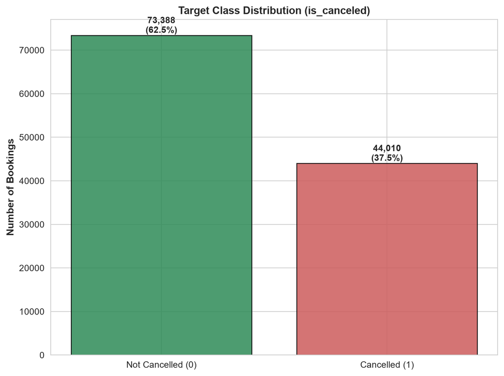

```python
display(Image(filename=str(reports_dir / "cancellation_class_distribution.png")))
```

**What to look for:** cancellation rate compared between City Hotel and Resort Hotel.

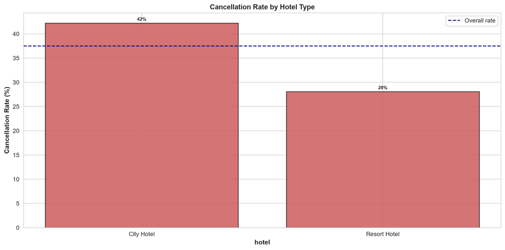

```python
display(Image(filename=str(reports_dir / "cancellation_rate_by_hotel_type.png")))
```

**Insight:** City Hotel bookings cancel more often than Resort Hotel bookings. **Why:** resort stays are often pre-planned vacations with more sunk commitment (flights, time off); city stays are frequently shorter, more flexible trips. **Business relevance:** City Hotel could consider marginally stricter deposit policies or earlier outreach on higher-lead-time bookings.

**What to look for:** overlapping distributions of lead time (days between booking and arrival) for cancelled vs. completed stays.

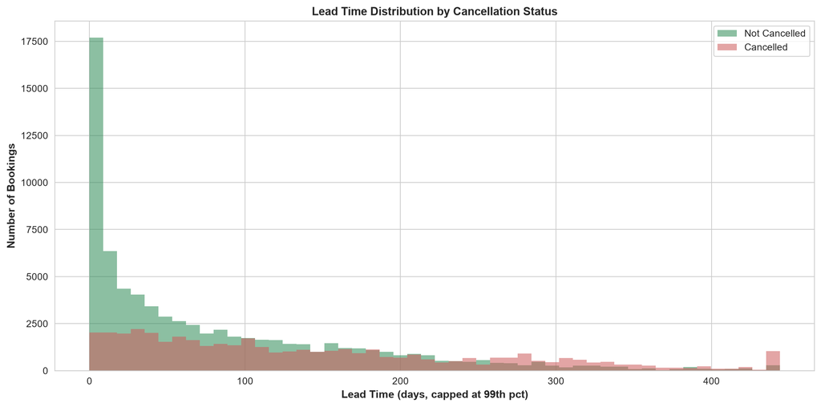

```python
display(Image(filename=str(reports_dir / "cancellation_rate_by_lead_time.png")))
```

**Insight:** cancelled bookings skew toward longer lead times. **Why:** more time between booking and arrival means more opportunity for plans to change. **Business relevance:** last-minute bookings are comparatively low-risk; bookings made far in advance deserve more monitoring.

**What to look for:** the same lead-time relationship, bucketed into clear groups (0-7, 8-30, 31-90, 91-180, 181-365, 365+ days).

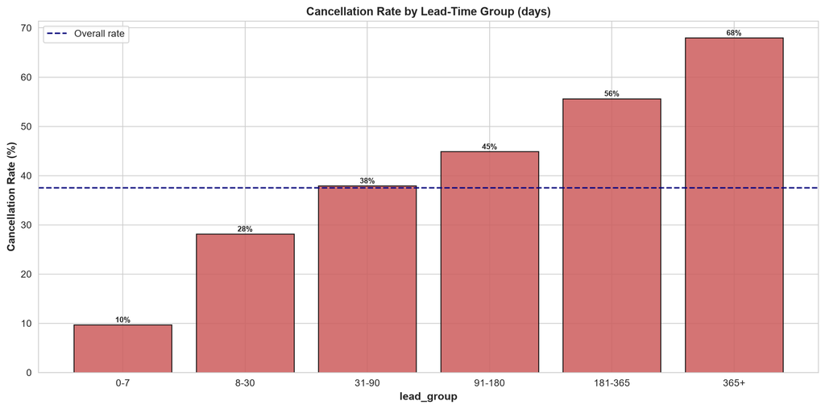

```python
display(Image(filename=str(reports_dir / "cancellation_rate_by_lead_time_group.png")))
```

**Insight:** cancellation rate rises step by step as lead time increases — a consistent, monotonic trend, not noise. **Business relevance:** lead-time bucket could directly inform tiered deposit or confirmation policies.

**What to look for:** cancellation rate broken down by the guest's arrival month.

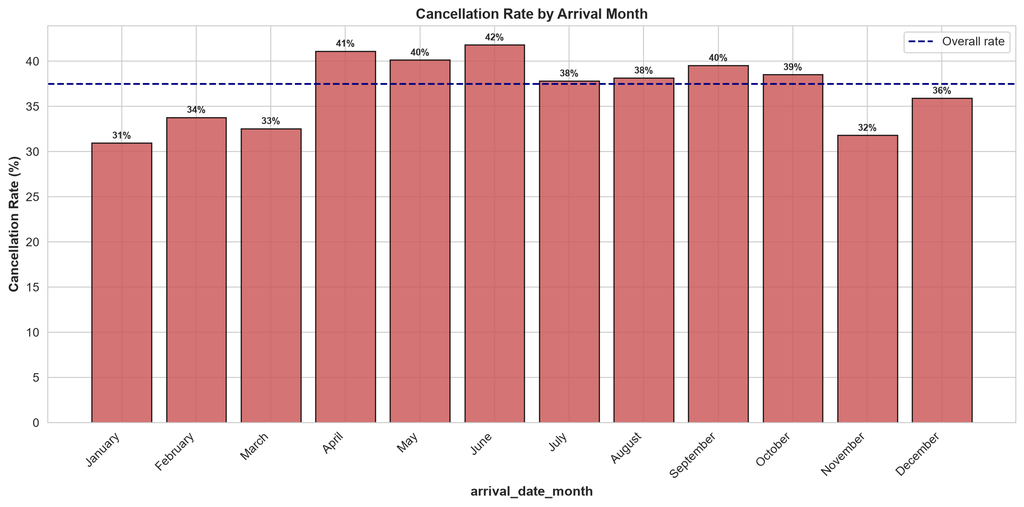

```python
display(Image(filename=str(reports_dir / "cancellation_rate_by_arrival_month.png")))
```

**Insight:** cancellation rate is not flat across the year — some months are structurally riskier. **Why:** seasonal demand, holidays, and weather-dependent travel plans shift booking commitment. **Business relevance:** overbooking buffers could be tuned seasonally instead of using one flat policy year-round.

**What to look for:** cancellation rate by how the booking was marketed/sold (Direct, Corporate, Online TA, Groups, etc.).

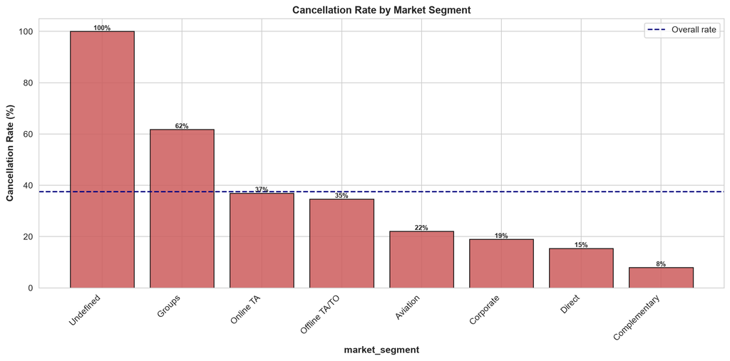

```python
display(Image(filename=str(reports_dir / "cancellation_rate_by_market_segment.png")))
```

**Insight:** Online TA and Group segments cancel more than Direct and Corporate. **Why:** direct/corporate bookings carry more accountability; online-agency bookings are often price-shopped across multiple sites with easy, penalty-free cancellation. **Business relevance:** channel-aware risk scoring could feed into revenue management decisions.

**What to look for:** cancellation rate by the operational channel the booking arrived through (Direct, TA/TO, Corporate, GDS).

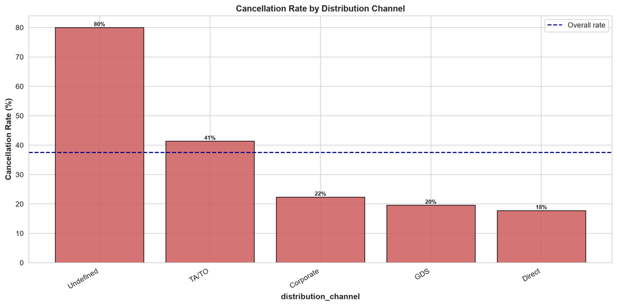

```python
display(Image(filename=str(reports_dir / "cancellation_rate_by_distribution_channel.png")))
```

**Insight:** mirrors the market-segment pattern — TA/TO channels cancel more than Direct/Corporate. **Business relevance:** reinforces that acquisition channel is a genuine, consistent risk signal, seen from two related angles.

**What to look for:** cancellation rate by deposit type — No Deposit, Non Refund, Refundable.

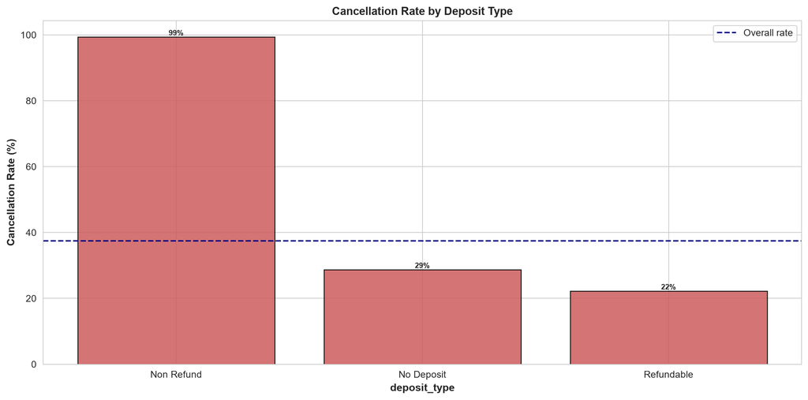

```python
display(Image(filename=str(reports_dir / "cancellation_rate_by_deposit_type.png")))
```

**What to look for:** cancellation rate by customer type — Transient (individual), Contract, Group, Transient-Party.

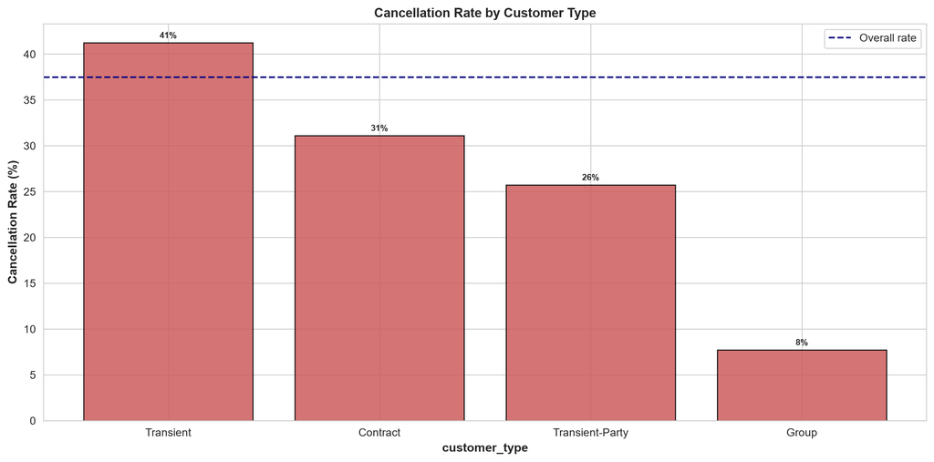

```python
display(Image(filename=str(reports_dir / "cancellation_rate_by_customer_type.png")))
```

**Insight:** individual Transient bookings cancel somewhat more than Contract or Group bookings. **Why:** individual travelers have fewer external commitments (no group coordination, no contract terms) tying them to the booking. **Business relevance:** negotiated-rate/contract customers could reasonably be treated as lower risk.

**What to look for:** cancellation rate by the room type originally reserved.

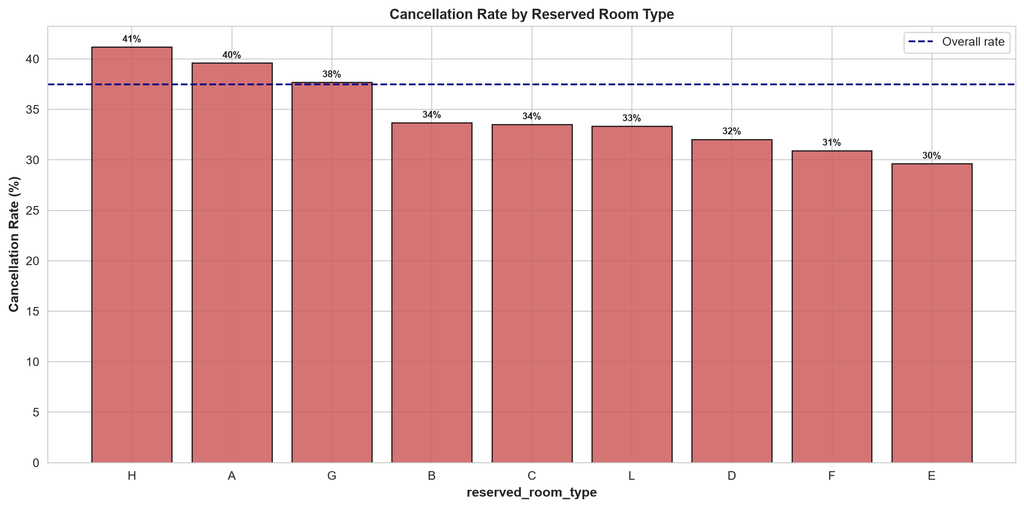

```python
display(Image(filename=str(reports_dir / "cancellation_rate_by_reserved_room_type.png")))
```

**Insight:** a mild, secondary signal — some room types show slightly higher cancellation rates than others. **Business relevance:** minor supporting input to a risk score, not something to act on by itself.

**What to look for:** cancellation rate by the room type actually assigned.

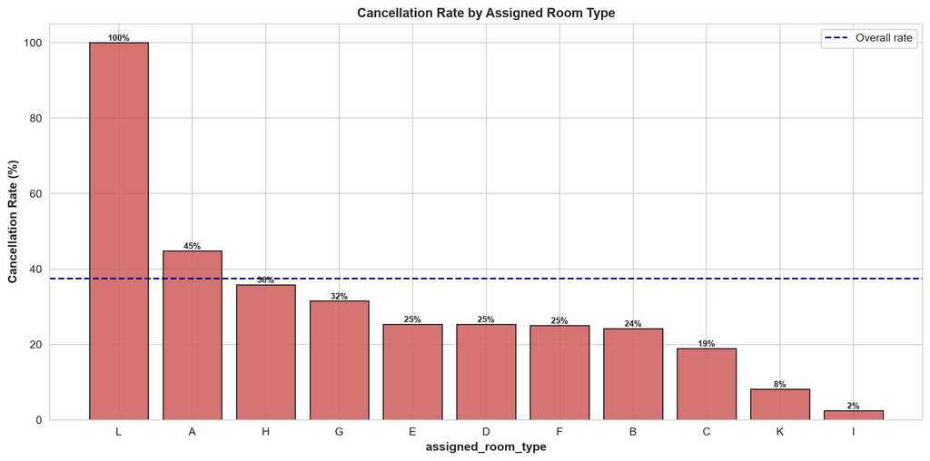

```python
display(Image(filename=str(reports_dir / "cancellation_rate_by_assigned_room_type.png")))
```

**Insight:** a similar, related pattern to the reserved room type. **Business relevance:** adds a little more resolution but tells largely the same story as reserved room type.

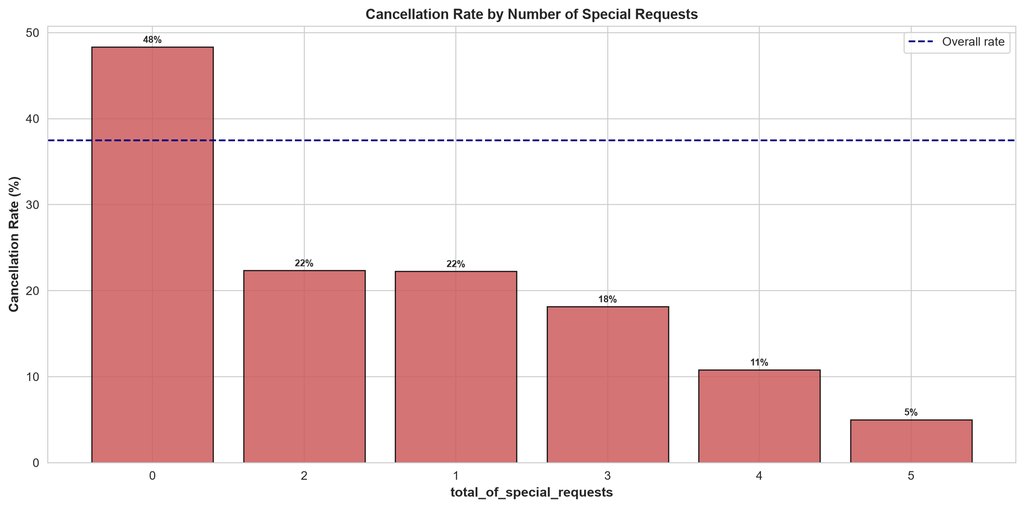

```python
display(Image(filename=str(reports_dir / "cancellation_rate_by_special_requests.png")))
```

**Insight:** more special requests correlates with a *lower* cancellation rate. **Why:** a guest who asks for a late check-in or a specific view has mentally invested in the trip's details. **Business relevance:** bookings with zero special requests could be flagged for light-touch confirmation outreach.

**What to look for:** cancellation rate grouped by how many times this guest has cancelled before.

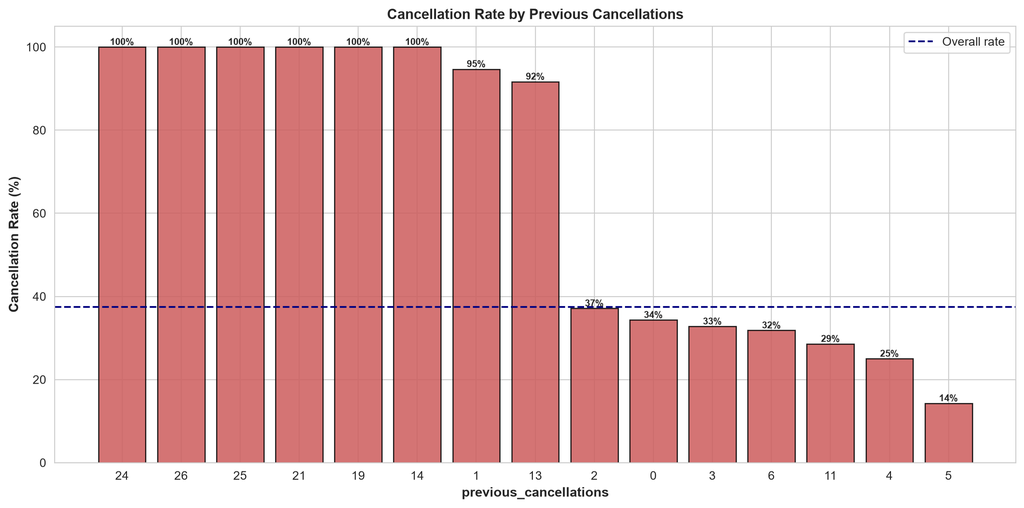

```python
display(Image(filename=str(reports_dir / "cancellation_rate_by_previous_cancellations.png")))
```

**What to look for:** cancellation rate by whether the guest requested a car parking space.

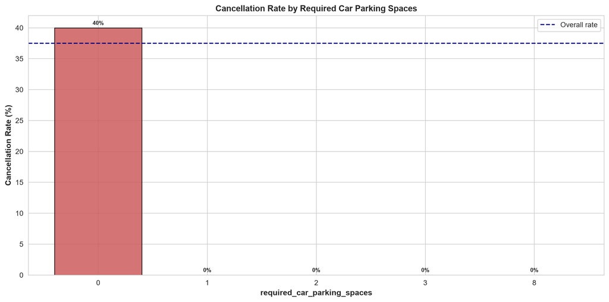

```python
display(Image(filename=str(reports_dir / "cancellation_rate_by_parking_spaces.png")))
```

**Insight:** needing parking correlates with a notably lower cancellation rate. **Why:** same logic as special requests — planning specific logistics signals real intent to arrive. **Business relevance:** another low-effort, already-collected commitment signal.

**What to look for:** correlation of numeric features against each other and against `is_canceled`, ordered by strength of relationship with the target.

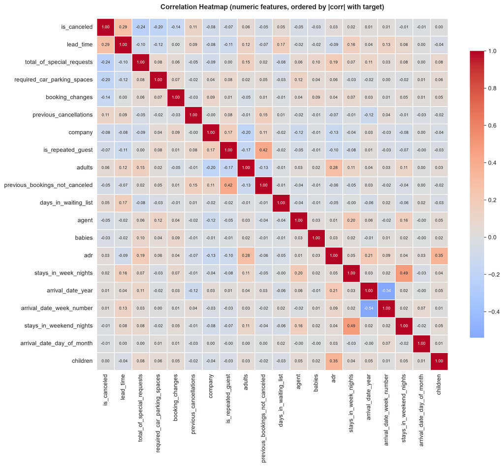

```python
display(Image(filename=str(reports_dir / "correlation_heatmap.png")))
```

**Insight:** no single numeric feature is strongly correlated with cancellation — the strongest, `lead_time`, is only 0.293. **Why this matters:** cancellation isn't explained by any one number rising or falling in isolation; it's explained by *combinations* of features (e.g., long lead time **and** a certain deposit type **and** a certain channel). **Business relevance:** this is early evidence that a simple scoring formula wouldn't work well here — it justifies testing more flexible, interaction-aware models in Section 6.

**What to look for:** boxplots flagging statistical outliers (via the IQR rule) across 13 key numeric fields.

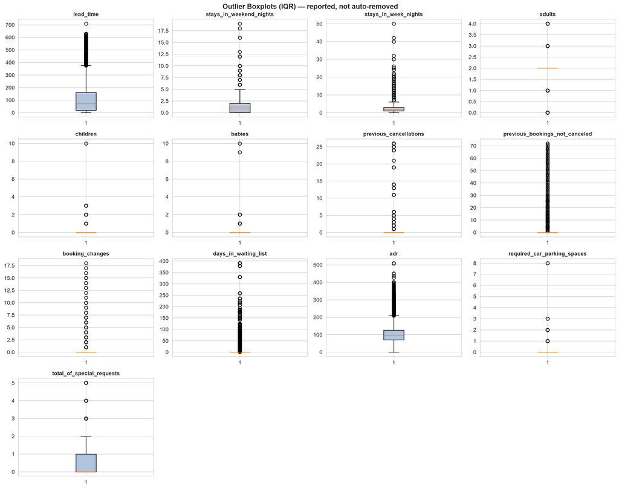

```python
display(Image(filename=str(reports_dir / "outlier_boxplots.png")))
```

**Insight:** fields like `adults` (24.9% flagged), `booking_changes` (15.1%), and `children` (7.2%) contain many statistical outliers — but these are legitimate rare bookings (large families, heavily modified reservations), not data errors. **Decision:** these were deliberately kept, not removed — tree-based models handle outliers well, and these tails carry real cancellation signal. **Business relevance:** shows the data was audited carefully, supporting trust in the downstream results.

### Common-scale comparison (display only)

The boxplots above use each feature's native units, so features on very different scales can't be compared side by side. Below we rescale **every** numeric feature to a shared range with `MinMaxScaler` (deliberately, not `StandardScaler` — z-scores are unbounded and wouldn't pin to a common axis). This rescaling is a **visualization artifact only**; it never touches the model pipeline (trees are scale-invariant, and the MLP scales inside its own pipeline).

**Why log scale:** several count features (`previous_bookings_not_canceled`, `days_in_waiting_list`, `booking_changes`) are heavily right-skewed — on a plain linear scale they bunch against the floor and their outlier structure disappears. Mapping every feature to `[1, 10]` and drawing it on a **log axis** spreads these skewed features out so outlier patterns across all 13 features become visible on one comparable axis. Computed on the pre-removal cleaned data so the outliers stay visible.

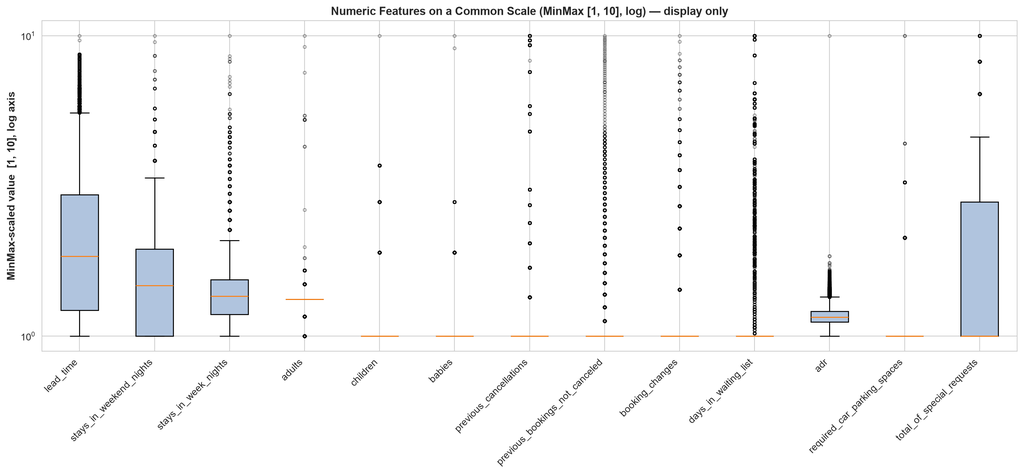

```python
from src.eda_analysis import plot_common_scale_outlier_panel

df_pre_removal = clean_hotel_booking_data(df_raw)
panel_paths = plot_common_scale_outlier_panel(df_pre_removal, reports_dir)
for _p in panel_paths:
    display(Image(filename=str(_p)))
```

## 5. Statistical Patterns and Business Insights

Pulling the EDA together, ranked roughly by strength:

1. **Deposit type** — by far the strongest relationship (99.4% cancel rate for Non-Refund). Flagged as a dataset-specific pattern to validate, not a settled fact.
2. **Lead time** — a clean, monotonic relationship: the further out a booking is made, the more likely it cancels.
3. **Previous cancellations** — guests who've cancelled before are meaningfully more likely to cancel again; behavior repeats.
4. **Special requests / parking spaces** — both act as "commitment" proxies: more engagement with trip specifics predicts follow-through.
5. **Market segment / distribution channel** — Online TA and Group bookings cancel more than Direct/Corporate, reflecting lower accountability in those channels.
6. **Hotel type / customer type** — City Hotel and individual Transient bookings cancel somewhat more than Resort Hotel and Contract/Group bookings, respectively.

**What surprised us going in:** we expected a numeric feature like `lead_time` or `adr` to dominate. Instead, **no numeric feature correlates strongly on its own** (the strongest is only 0.293) — the real signal was hiding in a *categorical* feature (`deposit_type`) and in *combinations* of features. That's exactly why we tested multiple, more flexible model types in the next section rather than relying on a simple formula.

## 6. Model Training

We trained and compared **five** classification models on the same 80,000-booking training set, each predicting both the cancellation class and a probability.

**Logistic Regression** *(linear baseline)*

- *How it works:* computes a weighted sum of every feature and squashes it through a curve into a 0–1 probability.
- *Why we tried it:* every classification project needs a linear baseline, to prove the more complex models are actually earning their complexity.
- *Strengths:* simple, fast to explain, a fair yardstick.
- *Weaknesses:* can only add up independent effects — it can't learn "long lead time only matters *combined with* a certain deposit type." It misses interactions.

**Decision Tree**

- *How it works:* asks a sequence of yes/no questions ("Is deposit Non-Refund? If not, is lead time over 150 days?"), splitting the data at each step.
- *Why we tried it:* the natural next step up from a linear model, and the building block for the two ensembles below.
- *Strengths:* naturally captures feature interactions; easy to visualize as a flowchart.
- *Weaknesses:* a single deep tree can memorize noise in training data (overfitting) — we cap its depth to keep it honest.

**Random Forest**

- *How it works:* builds 200 different decision trees, each on a random sample of data and features, then averages all their votes.
- *Why we tried it:* the standard, reliable next step after a single tree — "wisdom of the crowd" applied to trees.
- *Strengths:* averaging cancels out individual trees' mistakes — far more stable than one tree.
- *Weaknesses:* slightly slower and less interpretable than a single tree; on this data, it doesn't quite match boosting.

**MLP (Multi-Layer Perceptron — our deep learning model)**

- *How it works:* layers of artificial neurons, each a weighted sum passed through a non-linear activation, stacked to approximate complex curved patterns.
- *Why we tried it:* a fair, modern comparison point against tree-based methods.
- *Strengths:* in theory can model almost any pattern given enough data; the most flexible model tried.
- *Weaknesses:* needs feature scaling (the only model here we scale, and only inside its own pipeline); far slower to train; can overfit without early stopping.

**XGBoost**

- *How it works:* also builds many trees, but sequentially — each new tree is trained specifically to correct the mistakes of the trees before it, with built-in penalties to stop any one tree from dominating.
- *Why we tried it:* the industry-standard choice for tabular data with a mix of categorical and numeric features — exactly our situation.
- *Strengths:* typically the strongest performer on structured business data; fast to train even with hundreds of trees; naturally captures non-linear thresholds and interactions.
- *Weaknesses:* more hyperparameters to tune than a single tree; slightly less immediately interpretable than a shallow tree.

The cell below actually trains all five and evaluates each on the held-out test set.

```python
from src.modeling import train_and_evaluate, comparison_dataframe, select_best_model

fitted, results = train_and_evaluate(X_train_enc, y_train, X_test_enc, y_test)
```

```
  LogisticRegression   acc=0.816 f1=0.729 roc_auc=0.894 (71.5s)
```

```
  DecisionTree         acc=0.855 f1=0.801 roc_auc=0.929 (0.9s)
```

```
  RandomForest         acc=0.884 f1=0.835 roc_auc=0.957 (2.0s)
```

```
  XGBoost              acc=0.884 f1=0.841 roc_auc=0.956 (1.2s)
```

```
  MLP                  acc=0.864 f1=0.808 roc_auc=0.940 (12.6s)
```

## 7. Model Evaluation Metrics

**These are baseline (pre-tuning) results** — default hyperparameters, one-hot encoding, and the full feature set. XGBoost wins here and is the model carried forward into Section 10, where it is tuned, its categorical encoding is fixed, and post-booking leakage is removed to produce the canonical model.

```python
comparison = pd.read_csv(reports_dir / "classification_model_comparison.csv")
comparison.sort_values("roc_auc", ascending=False).reset_index(drop=True)
```

|  | model | accuracy | precision | recall | f1 | roc_auc | train_time_sec |
| --- | --- | --- | --- | --- | --- | --- | --- |
| 0 | XGBoost | 0.881975 | 0.860688 | 0.812967 | 0.836147 | 0.954260 | 1.195 |
| 1 | RandomForest | 0.879106 | 0.891188 | 0.767322 | 0.824630 | 0.953451 | 1.956 |
| 2 | MLP | 0.863138 | 0.838634 | 0.780755 | 0.808660 | 0.939212 | 18.727 |
| 3 | DecisionTree | 0.848388 | 0.838133 | 0.732095 | 0.781534 | 0.926501 | 0.921 |
| 4 | LogisticRegression | 0.805788 | 0.797565 | 0.637516 | 0.708616 | 0.874269 | 14.289 |

**What each metric means, why it matters here, and why XGBoost's score is good** (numbers below are the **baseline** XGBoost's, from the table above; the tuned and leakage-removed model in Section 10 shifts several of these):

- **Accuracy (88.2%)** — the percentage of all predictions that were correct. *Why it matters:* the simplest headline number. *Why 88.2% is good:* a hotel that just assumed "nobody cancels" would already be right 63% of the time — so 88.2% shows the model learned real patterns, not just the easy majority guess.
- **Precision (86.1%)** — of the bookings flagged "will cancel," how many actually did. *Why it matters:* controls false alarms. *Why 86.1% is good:* if staff act on a "high risk" flag, they're right about 6 times out of 7.
- **Recall (81.3%)** — of the bookings that actually cancelled, how many were caught in advance. *Why it matters:* the most business-critical metric here — a **missed** cancellation (false negative) is the costly error, since the hotel loses the chance to resell that room. *Why 81.3% is good:* roughly 4 out of every 5 real cancellations are caught before they happen.
- **F1-score (0.836)** — the harmonic mean of precision and recall. *Why it matters:* proves the model isn't gaming one metric at the other's expense (e.g., flagging everything to inflate recall). *Why 0.836 is good:* precision and recall are close together, showing genuine balance rather than a lopsided trade-off.
- **ROC-AUC (0.954)** — how well the model *ranks* bookings from riskiest to safest, across every possible decision threshold, not just the default 50% cutoff. *Why it matters:* our deliverable is a probability, not just yes/no, so this measures whether that probability is actually meaningful. *Why 0.954 is good:* 1.0 is a perfect ranking, 0.5 is a coin flip — 0.954 is very close to perfect.
- **Train time (1.2s)** — not a correctness metric, a practicality one. *Why it matters:* determines how cheaply the model can be refreshed. *Why 1.2s is good:* the model can be retrained daily or weekly as new booking data arrives, at negligible computing cost.

## 8. Why XGBoost Was Selected

*All figures below are baseline, pre-tuning (default hyperparameters); this section is about **algorithm** selection, and Section 10 then tunes the winner.*

| Model | Accuracy | Precision | Recall | F1 | ROC-AUC | Train time |
| --- | --- | --- | --- | --- | --- | --- |
| **XGBoost** | **0.882** | 0.861 | **0.813** | **0.836** | **0.954** | 1.2s |
| Random Forest | 0.879 | **0.891** | 0.767 | 0.825 | 0.953 | 2.0s |
| MLP | 0.863 | 0.839 | 0.781 | 0.809 | 0.939 | 18.7s |
| Decision Tree | 0.848 | 0.838 | 0.732 | 0.782 | 0.927 | 0.9s |
| Logistic Regression | 0.806 | 0.798 | 0.638 | 0.709 | 0.874 | 14.3s |

XGBoost wins on accuracy, recall, F1, and ROC-AUC — the four metrics that matter most here — while also being one of the fastest to train. Random Forest is close (0.953 vs 0.954 ROC-AUC) and actually has *better* precision, but it misses more real cancellations (76.7% recall vs XGBoost's 81.3%). Since a missed cancellation costs the hotel more than a false alarm, XGBoost's recall advantage tips the decision.

**Why ROC-AUC and F1 matter more than accuracy alone:** with 37% of bookings cancelling, a model that just guesses the majority class ("never cancels") would already score ~63% accuracy while being completely useless. ROC-AUC measures whether the model's *probabilities* are trustworthy across every threshold — the core requirement of this project — and F1 confirms the model isn't quietly sacrificing recall for precision (or vice versa) to game a single number. Logistic Regression's much lower ROC-AUC (0.874) is direct evidence it can't capture the interaction-driven patterns (deposit type × lead time × channel) that the tree and ensemble models can.

## 9. Confusion Matrix Explanation

[figure not shown]

```python
display(Image(filename=str(reports_dir / "confusion_matrix_xgboost.png")))
```

```python
cm = results["XGBoost"]["confusion_matrix"]
pd.DataFrame(
    cm,
    index=["Actual: Not Cancelled", "Actual: Cancelled"],
    columns=["Predicted: Not Cancelled", "Predicted: Cancelled"],
)
```

|  | Predicted: Not Cancelled | Predicted: Cancelled |
| --- | --- | --- |
| Actual: Not Cancelled | 21580 | 1798 |
| Actual: Cancelled | 2534 | 11486 |

## 10. Model Improvement: Tuning, Interpretability, and Leakage Removal

Sections 6–9 picked XGBoost as the strongest algorithm using its default, out-of-the-box settings. This section takes that starting point and improves it through five steps: checking how deep the trees should grow (10a), an automated search for the best overall settings (10b), fixing how two ID columns were being read by the model (10c), explaining what the model actually pays attention to (10d), and removing two fields that quietly gave the model information it would not have in real life (10e). The code behind every step lives in `src/tuning.py` and `src/explainability.py`; this section narrates what was done, why, and what was found.

### 10a. How deep should the trees grow?

Every decision tree inside XGBoost can be grown shallow or deep. Too shallow and the model misses real patterns (it *underfits*); too deep and it starts memorizing quirks of the training data that do not hold up on new bookings (it *overfits*). To find the right depth, we retrained the model repeatedly at tree depths from 2 to 14, each time checking its score both on the data it trained on and on held-back validation data it had not seen.

[figure not shown]

**What we found:** the model keeps genuinely improving through depth 6. Past depth 8, its score on the training data keeps climbing toward a perfect score, while its score on unseen validation data flattens out — the classic signature of overfitting. The single best validation score technically lands at depth 13, but that edge is razor-thin and unstable; the practical sweet spot is depth 9–11, which captures nearly all of the achievable accuracy without the extra overfitting risk. This is why the next step tunes several settings together rather than simply pushing depth as high as possible.

### 10b. Searching for the best overall settings

Tree depth is only one of several dials that control how XGBoost learns — others govern how much a tree is penalized for complexity, how fast the model learns from its mistakes, and how much of the data each tree sees. Rather than tune these by hand one at a time, we used an automated search tool (Optuna) that tries many combinations of these settings and keeps whichever combination scores best on repeated validation checks. The winning combination was then retrained once on the full training set and scored, for the first time, on the held-out test set — and every trial was automatically logged so the exact winning settings are reproducible.

[figure not shown]

**What we found:** tuning lifted the model's overall ranking quality (ROC-AUC) from 0.954 to 0.962 and its ability to catch real cancellations (recall) from 81.3% to 83.9% — a meaningful gain over the untuned defaults used in Sections 6–9.

### 10c. Fixing how two ID columns were read

`agent` and `company` are ID numbers — which travel agent or company a booking came through — not real quantities. Agent "535" is not *more* than agent "2" any more than phone extension 535 is more than extension 2. Up until this point the model had been reading both columns as plain numbers, which can quietly bias it toward treating a larger ID as somehow more significant. Here we told the model to treat both columns as pure labels instead (using XGBoost's own built-in support for that), and re-ran the exact same tuned settings from 10b so the only thing that changed was this encoding.

*Note: `company` is missing 94.3% of the time, so its main learnable signal is closer to "was a company involved at all" than "which specific company" — there simply is not enough data behind most individual company IDs to learn more than that.*

[figure not shown]

**What we found:** the fix produced a small but consistent improvement across every metric (ROC-AUC 0.9621 → 0.9625, recall 83.9% → 84.2%) — and, more importantly, turned `agent` into a genuinely interpretable feature instead of a meaningless magnitude, which matters for the explainability step next.

### 10d. What is the model actually paying attention to?

A model can score well without anyone understanding *why* it makes the calls it makes — a problem if hotel staff are expected to trust and act on its predictions. We used a technique called SHAP, which measures how much each individual field on a booking pushed that specific prediction up or down, computed only on the held-out test bookings the model never trained on.

[figure not shown]

**Global ranking:** the strongest drivers of a cancellation prediction are `country` (mostly explained by Portugal, the hotels' home market), `deposit_type` (specifically its Non-Refund option), then `agent`, `total_of_special_requests`, `lead_time`, and `previous_cancellations` — all patterns that match what a hotel manager would expect. Recasting `agent` as a category (10c) is exactly what gave it real, interpretable importance; `company`, by contrast, sits near the bottom of the ranking (25th out of 29 fields) — exactly as expected, given how little usable signal survives its 94.3% missingness.

Two individual examples show the model's reasoning on single bookings — one it got right, one it got wrong:

[figure not shown]

**A red flag SHAP surfaced:** two fields — `assigned_room_type` and `booking_changes` — showed up as moderate drivers, but neither is actually known at the moment a booking is *created*: the assigned room can change later, and booking changes accumulate over time. That is addressed directly in the next step.

### 10e. Removing information the model would not really have

The two fields flagged in 10d — `assigned_room_type` and `booking_changes` — are only known *after* a booking already exists, not at the moment it is made. A model that uses them looks better in testing than it would ever perform in production, because in production neither value exists yet when a prediction is actually needed. This is the same category of problem, on a smaller scale, as the `reservation_status` leakage removed during initial cleaning (Section 3). We dropped both fields and retrained the same tuned, categorical-aware pipeline from 10c/10d on the reduced feature set.

[figure not shown]

**What we found — the honest picture:**

| Model | Accuracy | Precision | Recall | F1 | ROC-AUC |
| --- | --- | --- | --- | --- | --- |
| Optuna-tuned (IDs as numbers) | 0.8929 | 0.8705 | 0.8390 | 0.8545 | 0.9621 |
| + categorical fix | 0.8939 | 0.8708 | 0.8418 | 0.8561 | 0.9625 |
| **+ leakage removed (production model)** | 0.8871 | 0.8635 | 0.8299 | 0.8464 | 0.9588 |

Removing the two leaky fields costs a small amount of measured performance (ROC-AUC drops from 0.962 to 0.959, recall from 84.2% to 83.0%) — but that drop is the honest price of a model that only uses information actually available the moment a booking is made. This final version, `leakage_removed_xgb`, is the canonical model this project delivers.

**Double-checking with SHAP one more time.** After removing those two fields, we re-ran the same explainability check on the new, canonical model to confirm nothing else quietly stepped in to fill the gap they left behind.

[figure not shown]

**What we found:** the same at-booking-time fields still lead the ranking (`country`, `deposit_type`, `agent`, `total_of_special_requests`, `lead_time`, `previous_cancellations`); the two removed fields are gone, and the one remaining borderline-timing field (`days_in_waiting_list`) stays negligible near the bottom of the ranking — confirming the leakage removal did not just shift the problem elsewhere.

**Why false negatives matter most for hotel revenue:** a false negative means the hotel had no warning — the room was assumed safe, and then it cancelled anyway, often too late to resell at full value. A false positive just costs a slightly unnecessary follow-up call. That asymmetry is exactly why we weighted **recall** so heavily when comparing models in Section 8 — minimizing false negatives is the metric with the direct revenue impact.

## 11. Prediction Workflow

How a single new booking becomes a prediction:

```
Raw booking data (partial or full)
        |
        v
Fill missing fields with sensible defaults
        |
        v
One-hot encode categoricals (same encoder fitted during training)
        |
        v
Trained XGBoost model -> predict_proba()
        |
        v
Cancellation probability (0.0 - 1.0)
        |
        v
Threshold at 0.5 -> final label ("Cancelled" / "Not Cancelled")
```

Below, `src/predict.py`'s `predict_cancellation()` runs this exact pipeline on two contrasting real examples.

```python
from src.predict import predict_cancellation

high_risk = {
    "hotel": "Resort Hotel", "lead_time": 350, "adults": 2,
    "deposit_type": "Non Refund", "previous_cancellations": 1,
    "total_of_special_requests": 0,
}
low_risk = {
    "hotel": "City Hotel", "lead_time": 10, "deposit_type": "No Deposit",
    "total_of_special_requests": 2, "required_car_parking_spaces": 1,
}

print("High-risk booking ->", predict_cancellation(high_risk))
print("Low-risk booking  ->", predict_cancellation(low_risk))
```

```
High-risk booking -> {'prediction': 1, 'label': 'Cancelled', 'cancellation_probability': 0.9999}
Low-risk booking  -> {'prediction': 0, 'label': 'Not Cancelled', 'cancellation_probability': 0.0017}
```

## 12. Offline vs Online Inference

```
                    +-------------------+
                    |   src/train.py    |   trains XGBoost, logs to MLflow,
                    |  (train + store)  |   saves models/best_cancellation_model.pkl
                    +---------+---------+
                              |
                saved model  |
              +---------------+---------------+
              |                               |
              v                               v
 +--------------------------+     +--------------------------+
 | src/predict_offline.py   |     |        src/api.py        |
 | OFFLINE: batch CSV in,   |     | ONLINE: FastAPI service, |
 | CSV with predictions out |     | one booking per request  |
 +--------------------------+     +--------------------------+
   used for: nightly reports,       used for: live booking-system
   bulk scoring, dashboards         integration, real-time alerts
```

- **`src/train.py`** — the only place the model learns. Run periodically (e.g. weekly) to refresh the model on new data; every run is logged to MLflow.
- **`src/predict_offline.py`** — batch scoring. Reads a CSV of new bookings, writes back a CSV with `prediction`, `label`, `cancellation_probability` columns added. Efficient for scoring thousands of bookings at once (e.g. a nightly job).
- **`src/api.py`** — real-time scoring. A FastAPI service (`POST /predict`) a live booking system could call the instant a reservation is made, getting an answer back in milliseconds.

Below: a small offline batch demo, then the same model called through the online API.

```python
from src.predict import predict_batch

new_bookings = df_raw.drop(
    columns=["is_canceled", "reservation_status", "reservation_status_date"]
).sample(5, random_state=7)
scored = predict_batch(new_bookings)
scored[["hotel", "lead_time", "deposit_type", "prediction", "label", "cancellation_probability"]]
```

|  | hotel | lead_time | deposit_type | prediction | label | cancellation_probability |
| --- | --- | --- | --- | --- | --- | --- |
| 71902 | City Hotel | 53 | No Deposit | 1 | Cancelled | 0.6938 |
| 51736 | City Hotel | 158 | Non Refund | 1 | Cancelled | 0.9996 |
| 101138 | City Hotel | 48 | No Deposit | 0 | Not Cancelled | 0.3049 |
| 28656 | Resort Hotel | 383 | No Deposit | 0 | Not Cancelled | 0.0037 |
| 52793 | City Hotel | 69 | Non Refund | 1 | Cancelled | 0.9996 |

```python
from fastapi.testclient import TestClient
from src.api import app

client = TestClient(app)
response = client.post("/predict", json={
    "hotel": "Resort Hotel", "lead_time": 350, "deposit_type": "Non Refund",
})
print(response.status_code, response.json())
```

```
200 {'prediction': 1, 'label': 'Cancelled', 'cancellation_probability': 0.9996}
```

## 13. MLflow Experiment Tracking

Every model past the five-way baseline was logged to MLflow under the experiment `hotel_cancellation_classification`, so the full improvement path is reproducible from run history rather than reconstructed from code diffs. Each run records its parameters, metrics, a confusion-matrix artifact and the fitted model. The table below is pulled **live from the tracking store** (`mlflow.db` at the project root) and shows the four canonical runs in order:

- **`baseline`** — default XGBoost from the five-model comparison (Sections 6–9).
- **`optuna_tuned_xgb`** — Optuna-tuned hyperparameters (Section 10b).
- **`categorical_fix_xgb`** — `agent`/`company` recast as native categoricals (Section 10c).
- **`leakage_removed_xgb`** — post-booking leakage removed; the **canonical production model** (Section 10e).

```python
import mlflow

MLFLOW_DB = root / "mlflow.db"
mlflow.set_tracking_uri(f"sqlite:///{MLFLOW_DB.as_posix()}")

runs = mlflow.search_runs(experiment_names=["hotel_cancellation_classification"])
run_order = ["baseline", "optuna_tuned_xgb", "categorical_fix_xgb", "leakage_removed_xgb"]

def _metric(row, key):
    val = row.get(f"metrics.test_{key}")
    if val is not None and pd.notna(val):
        return val
    return row.get(f"metrics.{key}")

rows = []
for name in run_order:
    match = runs[runs["tags.mlflow.runName"] == name]
    if match.empty:
        continue
    r = match.sort_values("start_time").iloc[-1]
    rows.append({
        "run": name,
        "accuracy": _metric(r, "accuracy"),
        "precision": _metric(r, "precision"),
        "recall": _metric(r, "recall"),
        "f1": _metric(r, "f1"),
        "roc_auc": _metric(r, "roc_auc"),
    })

mlflow_comparison = pd.DataFrame(rows).set_index("run").round(4)
mlflow_comparison
```

| run | accuracy | precision | recall | f1 | roc_auc |
| --- | --- | --- | --- | --- | --- |
| baseline | 0.8820 | 0.8607 | 0.8130 | 0.8361 | 0.9543 |
| optuna_tuned_xgb | 0.8929 | 0.8705 | 0.8390 | 0.8545 | 0.9621 |
| categorical_fix_xgb | 0.8939 | 0.8708 | 0.8418 | 0.8561 | 0.9625 |
| leakage_removed_xgb | 0.8871 | 0.8635 | 0.8299 | 0.8464 | 0.9588 |

**Reading the progression.** `optuna_tuned_xgb` lifts ROC-AUC from the baseline's 0.954 to 0.962 and recall from 0.813 to 0.839 — the tuning pays off. The native-categorical fix (`categorical_fix_xgb`) adds a small further gain and, more importantly, turns `agent` into an interpretable feature (Section 10c). `leakage_removed_xgb` then gives back a slice of that performance (ROC-AUC 0.959, recall 0.830) — the deliberate, measured cost of dropping the two post-booking features that would not exist at prediction time. That last row is the number we stand behind, because it is the only one that is honest about when the model actually runs. Run `mlflow ui --backend-store-uri sqlite:///mlflow.db` from the project root to compare the runs visually.

## 14. Business Value for Stakeholders

**How a hotel would actually use this:**

- **Identify high-risk bookings** — sort upcoming reservations by cancellation probability to see which ones need attention first.
- **Adjust inventory** — factor per-booking risk into how many rooms are held back or released for resale.
- **Overbooking strategy** — replace a flat historical overbooking percentage with a probability-weighted, booking-by-booking estimate.
- **Customer outreach** — trigger a confirmation call, deposit reminder, or incentive for bookings flagged as high risk, while leaving low-risk bookings alone to save staff time.
- **Reduce revenue loss** — every cancellation caught early (recall: 83.0%) is a room that can potentially be resold instead of discovered empty at the last minute.

This is decision **support** — the output is a probability a human uses to make a call, not an automated cancellation or rebooking action.

## 16. Future Work

**Phase 3 — guest-experience signal.**

- **TripAdvisor review sentiment analysis** — mine the currently unused `data/tripadvisor_hotel_reviews.csv` for guest-sentiment features, pairing cancellation risk with satisfaction signals.
- **Concierge recommendation engine** — combine booking and review data to suggest upsells, better room matches, and personalized offers.

**Phase 4 — production deployment.**

- **Deploy the API** into an existing front-desk / property-management system for live, real-time scoring, with authentication and request logging.
- **Monitoring and drift detection** — track prediction quality and input drift over time as booking patterns shift, alerting when retraining is due.
- **Scheduled retraining** on a regular cadence — cheap to run (~1s training time) — plus a **stakeholder dashboard** surfacing per-booking risk and aggregate trends.
- **Validate on a second hotel's live data** — the key open question is whether the patterns learned here (especially the deposit-type signal) generalize beyond this dataset.

## 17. Q&A Preparation

**1. Why XGBoost over Random Forest — they're almost tied?** They're close (95.4% vs 95.3% ROC-AUC), but XGBoost has meaningfully better recall (81.3% vs 76.7%) — it catches more real cancellations, the costlier error to miss. It's also faster to train. (These are the baseline algorithm-selection numbers; the winner is then tuned in Section 10.)

**2. Why not Deep Learning as the primary model?** We did train one (the MLP) — 93.9% ROC-AUC, solidly good but below XGBoost's 95.4%, while taking 15x longer to train. Neural nets tend to shine on unstructured data like images/text; for structured tabular data like ours, boosted trees usually win.

**3. Why ROC-AUC as the primary metric instead of accuracy?** Our deliverable is a probability, not just yes/no. ROC-AUC measures whether that probability ranking is trustworthy across every threshold. Accuracy alone is also misleading here since 63% of bookings don't cancel.

**4. Precision vs recall — why prioritize recall?** A missed cancellation (false negative) costs a resellable room; a false alarm just costs a follow-up call. The downside of missing cancellations is bigger, so we favor recall — while keeping precision high enough (86%) that alerts stay trustworthy.

**6. Does the dataset have bias?** Yes, at least one clear case: the Non-Refund-deposit-cancels-99%-of-the-time pattern is unusually strong and dataset-specific — flagged explicitly rather than presented as universal truth.

**7. How would you deploy this in production?** Two paths already exist: a batch job (`predict_offline.py`) for scheduled scoring, and a real-time API (`api.py`) a booking system could call instantly. Production would add monitoring, auth, and scheduled retraining on top.

**8. Why MLflow instead of just Git?** Git tracks code changes; it doesn't track what happened when that code ran — which hyperparameters, what accuracy, which model file resulted. MLflow logs all of that automatically per run, which is how Section 13 reconstructs the full baseline → tuned → categorical-fix → leakage-removed progression.

**9. Why were `assigned_room_type` and `booking_changes` removed — and what did it cost?** SHAP (Section 10d) showed both as moderate drivers, but neither value exists at booking creation: the assigned room can change at check-in, and booking changes accumulate over the booking's life. Both are therefore post-booking leakage for an at-booking-time model. Removing them lowered test ROC-AUC from 0.962 to 0.959 and recall from 0.842 to 0.830 — a small, deliberate cost to get a score that's honest about when the model actually runs. `leakage_removed_xgb` is the canonical model.

**10. What happens if a booking is missing most of its fields?** Missing fields are filled with sensible defaults from training data, so the model always receives a complete input — though more missing data means the prediction leans more heavily on defaults.

**11. How do you know the model generalizes beyond this dataset?** We don't yet — that's the most important next step. Strong test performance shows it generalizes *within* this dataset's distribution; validating on a different hotel's live data is the real test.

**12. Why one-hot encoding instead of target encoding?** One-hot is simple, safe against leakage (doesn't use the target to encode features), and works well with tree-based models; rare categories are bucketed to control dimensionality. The two high-cardinality ID columns (`agent`/`company`) are handled separately as native XGBoost categoricals (Section 10c).

**13. Why not scale/normalize all the features?** Tree-based models (4 of 5 candidates) are scale-invariant, so normalizing adds complexity with zero benefit. The MLP is the one exception — scaled only inside its own pipeline.

**14. How often would this need to be retrained?** No fixed answer without live monitoring, but training takes ~1 second, so cost isn't the constraint — weekly or even daily retraining is easy to support.

**15. Why isn't `reservation_status` used as a feature? Isn't more data always better?** Not when it's leakage — one of its values is literally "Canceled," so it encodes the target directly. It was never part of the feature set (dropped during cleaning); a model using it would look perfect in testing but be useless in production, since that field doesn't exist yet at prediction time. The same reasoning drove removing `assigned_room_type` and `booking_changes` (see Q9).

**16. How confident are you in which features matter most?** Feature importance comes from SHAP on the trained model (Section 10d), not guesswork — `country`, `deposit_type` and `agent` lead, consistent with the EDA patterns in Sections 4–5. Whether that exact weighting holds on a different hotel's data is a separate, open question worth validating.

**17. Is the model interpretable enough for staff to trust it?** Yes — beyond overall metrics and the confusion matrix, we explain *individual* predictions with SHAP (Section 10d): a beeswarm of global drivers, a dependence plot for the top feature, and per-booking waterfalls showing exactly why a specific booking scored the way it did ("why did this booking score 92%?").

**19. What's the risk of the model being wrong in a way that hurts guest experience?** Mainly false positives triggering an unwanted intervention. That's why we track precision (86%) alongside recall — false alarms stay a controlled minority.

**20. What's the single biggest risk in this project right now?** That the model's strongest signal — deposit type — reflects a pattern in this historical dataset that may not carry over cleanly to live, current bookings. Before this drives real financial decisions, that assumption needs testing against fresh data.

## 18. Summary and Conclusion

**Metric progression across the three tuned iterations** (test set; the "honesty cost" of removing leakage is the final row):

| Model | Accuracy | Precision | Recall | F1 | ROC-AUC |
| --- | --- | --- | --- | --- | --- |
| `optuna_tuned_xgb` (IDs as numeric) | 0.8929 | 0.8705 | 0.8390 | 0.8545 | 0.9621 |
| `categorical_fix_xgb` (native categorical) | 0.8939 | 0.8708 | 0.8418 | 0.8561 | 0.9625 |
| **`leakage_removed_xgb` (production)** | 0.8871 | 0.8635 | 0.8299 | 0.8464 | 0.9588 |

**Key decisions and why:**

- **Targeted, rule-based row removal instead of a blanket IQR/outlier trim** — rare-but-valid extremes (long lead times, many prior cancellations) carry genuine cancellation signal, so only domain-impossible rows (non-positive ADR, zero-occupancy, absurd party sizes) were dropped.
- **`agent`/`company` as native XGBoost categoricals rather than numeric passthrough** — they are IDs, not magnitudes; treating `agent=535` as "greater than" `agent=2` is meaningless, and the fix turned `agent` into the model's 3rd-strongest, interpretable feature.
- **Removing `assigned_room_type` and `booking_changes` despite the performance they added** — SHAP flagged both as moderate drivers, but neither value exists at booking creation, when the model actually runs. Keeping them would inflate test scores while leaking the future; removing them (ROC-AUC 0.962 → 0.959, recall 0.842 → 0.830) buys an honest production number.
- **ROC-AUC and recall as the primary metrics** — the deliverable is a trustworthy probability, and a missed cancellation costs more than a false alarm, so ranking quality and recall matter more than headline accuracy.

**Deferred to future phases:** guest-experience signal from the unused TripAdvisor review data (sentiment analysis), a concierge recommendation engine, and productionizing the served API with monitoring, drift tracking and a stakeholder dashboard.